# Lecture 3: Sampling and Inferential Statistics

## `R` and normal distributions

We can use the normal distribution to find percentiles or probabilities. In the same way, we can get the z score associated with a given probability using the `qnorm` function.

```r
qnorm(p = 0.8, mean = 0, sd = 1)
```

```
[1] 0.8416212
```

```r
openintro::normTail(m = 0, s= 1, L = 0.8416)
```

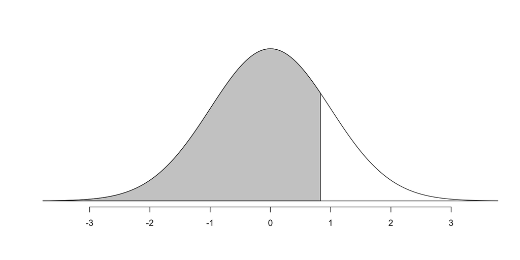

## Your turn! #4

1. Use `pnorm` to confirm the figure on slide 65, i.e., within +/- 1 (2) standard deviation of the mean, the standard normal distribution contains 68% (95%) of observations.
2. A region has household incomes with mean $\mu$ = 58,000 euros and standard deviation $\sigma$ = 15,000 euros. An economist surveys 100 randomly selected households. What is the probability that the sample mean income is less than 55,000 euros?
3. A country’s true unemployment rate is 6.2%. A labor economist draws a random sample of 1,000 working-age adults. What is the probability that the sample unemployment rate falls between 5% and 7%?
4. Monthly consumer spending at retail stores has mean $\mu$ = 320 euros and standard deviation $\sigma$ = 85 euros. A retail analyst collects data from 50 randomly selected consumers. Below what value does the lowest 10% of sample mean spending fall?

## What about (small) samples?

If $n$ is small and/or $\sigma$ is unknown, the standardized sample mean follows a **Student $t$ distribution** instead of normal.

$$T = \frac{\bar{X_n} - \mu}{S/\sqrt{n}} \sim t_{n-1}$$
where $n-1$ are the **degrees of freedom**.

The $t$ distribution has heavier tails than normal (more uncertainty), which makes sense for small samples.

When $n \to \infty$, the $t$ distribution converges to the normal distribution.

## Illustration: t vs. Normal for different sample sizes

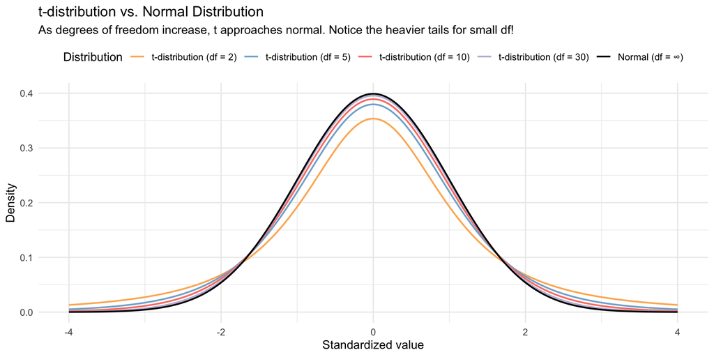

**Key insight:** For small samples (small $df$), the $t$-distribution has **heavier tails** than normal, meaning more extreme values are more likely. This gives wider confidence intervals and more conservative tests—appropriate when we have less information!

## Fun fact: History of the *t* distribution

The Student $t$ distribution was developed by W. S. Gosset in 1908.

Gosset worked for the Guinness brewery, which would not permit him to publish research in his own name. So he used the pseudonym **“Student.”**

Thus, the distribution is known as the **Student $t$ distribution**—named after a pseudonym!

The $t$ distribution is crucial for small-sample inference and remains one of the most widely used distributions in statistics.